# Exam 1

Nazali Dat

2024-09-30

# Exam 1

```r
library(tidyverse)
```

```r
library(tinytex)
library(ggthemes)
library(ggplot2)
```

### 1. (5 points) Load the data called dat.nsduh.small.csv. Take a look at the data.

```r
#setwd("C:/Users/mel47/OneDrive/Desktop/CRIM 1200 - FALL 2024/Exam1")
dat <- read_csv("dat.nsduh.small.csv")
```

Answer: I loaded the data

### 2. (5 points) Read the codebook. What do these variables represent: mjage, iralcage, sexatract, speakengl, and irsex?

Answer: mjage represents age when first used marijuana/hashish; iralcage represeted alcohol age of first use-imputation revised; sexatract represents sexual attraction; speakengl represents how well the subject speaks english; and irsex is (imputation revised) gender

### 3. (5 points) What type of stat variables are the variables from #2?

```r
levels(as.factor(dat$mjage))
```

```
##  [1] "7"  "9"  "10" "11" "12" "13" "14" "15" "16" "17" "18" "19" "20" "21" "22"
## [16] "25" "27" "30" "32" "33" "35"
```

```r
class(dat$mjage)
```

```
## [1] "numeric"
```

```r
levels(as.factor(dat$iralcage))
```

```
##  [1] "5"  "7"  "8"  "9"  "10" "11" "12" "13" "14" "15" "16" "17" "18" "19" "20"
## [16] "21" "23"
```

```r
class(dat$iralcage)
```

```
## [1] "numeric"
```

```r
levels(as.factor(dat$sexatract))
```

```
## [1] "1"  "2"  "3"  "4"  "5"  "6"  "99"
```

```r
class(dat$sexatract)
```

```
## [1] "numeric"
```

```r
levels(as.factor(dat$speakengl))
```

```
## [1] "1" "2" "3"
```

```r
class(dat$speakengl)
```

```
## [1] "numeric"
```

```r
levels(as.factor(dat$irsex))
```

```
## [1] "1" "2"
```

```r
class(dat$irsex)
```

```
## [1] "numeric"
```

Answer: All variables fall under the R variable numeric type; meaning that they should all be quantitative. However, I think speakengl, sexatract, and irsex are categorical as while they use the numerical output as catergories as per the code book. For example, irsex outputs canbe either (1) or (2); which can either indicate male or female as gender categories.

### 4. (5 points) Do visual EDA for mjage and iralcage, separately. (Hint: To compare the plots, make the axes limits, x and y, be the same for both plots. Also, try out different numbers of bins to see how they change.)

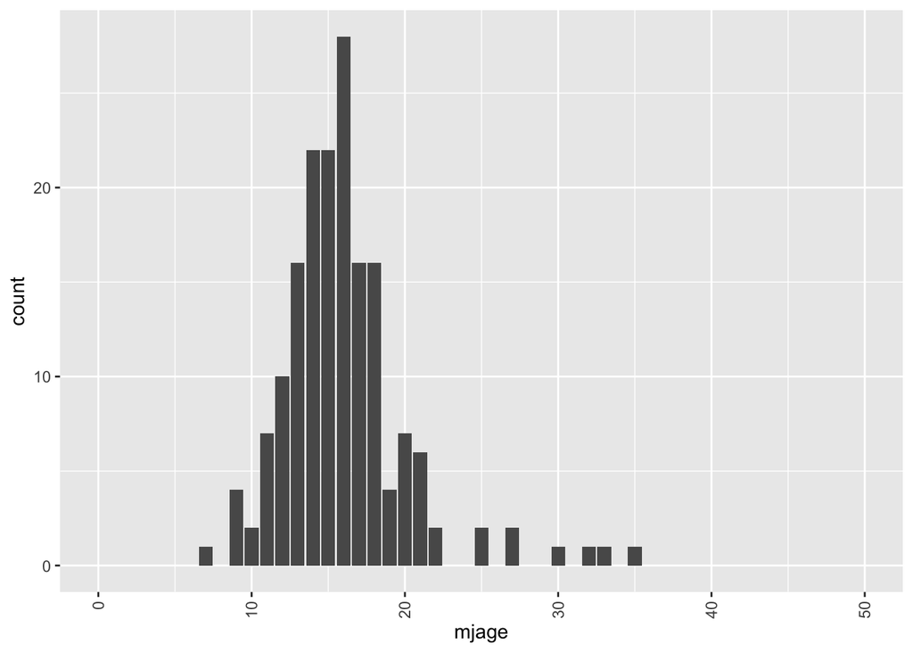

```r
#visual eda with mjage
dat %>%
  ggplot(aes(mjage)) +
  geom_bar() +
  xlim(0,50) +
  theme(axis.text.x = element_text(angle=90, vjust=.5, hjust=1))
```

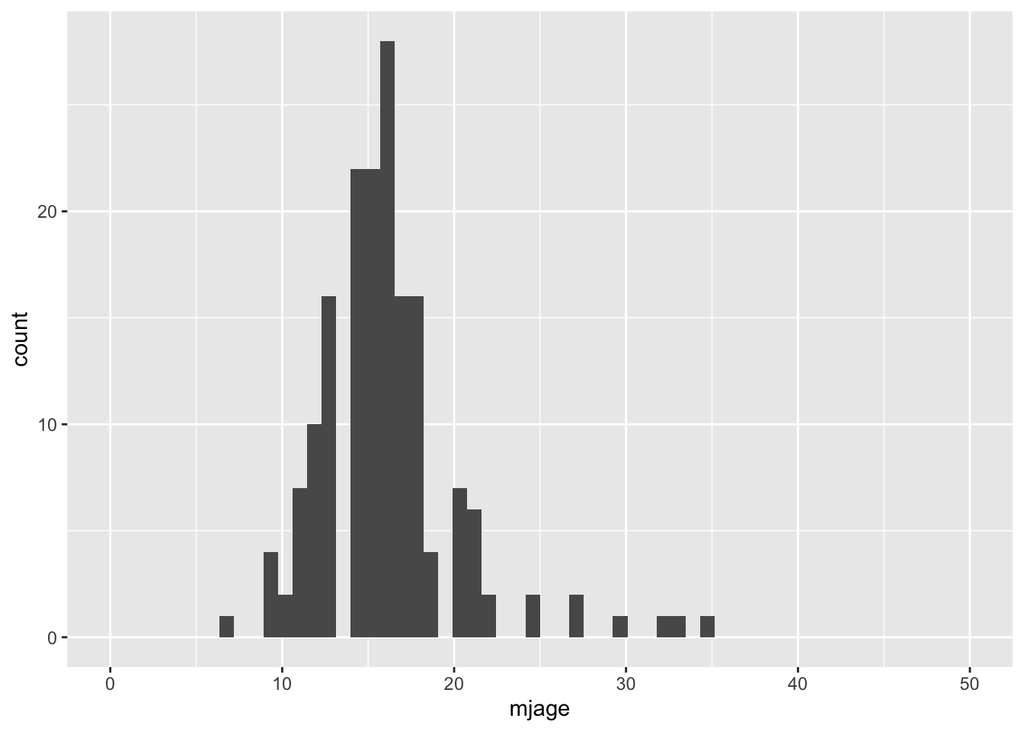

```r
dat %>%
  ggplot(aes(x=mjage))+
  geom_histogram(bins=60)+
  xlim(0,50)
```

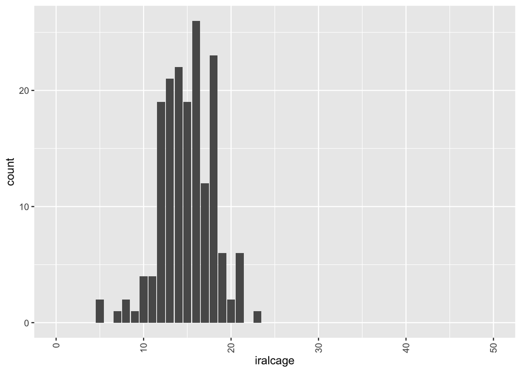

```r
#skewed left?


#visual eda for iralcage
dat %>%
  ggplot(aes(iralcage)) +
  geom_bar() +
  xlim(0,50) +
  theme(axis.text.x = element_text(angle=90, vjust=.5, hjust=1))
```

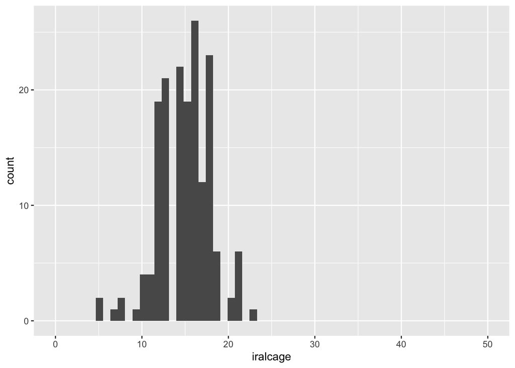

```r
dat %>%
  ggplot(aes(x=iralcage))+
  geom_histogram(bins=60)+
  xlim(0,50)
```

```r
#I played with limits for both; tried 30,100 and 50; im settling for 50.; ive also played with bin size; im setting it at 60 but i think 100 might also be telling
```

Answer: I created the plots; i made 2 seperate ones for each just to compare further

### 5. (5 points) Compare the two plots. How are they different and how are they similar? What theory do you have to explain these differences?

Answer: They are similar because when I increase the bin size; there are more gaps between points. Mjage is skewed right and iralcage looks like its skewed (slightly?) to the left. Mjage also looks like its unimodal while iralcage looks almost bimodal, as there are two tall points surrounded by less tall points. I can try to explain this difference by making the indeference that around 16, kids try marjuana for the first time, maybe because its easier to access; anf then the bimodal skew in age of first alcohol usage both being highest at 16 and 18; might be explained by culture. I know certian cultures will be okay with their children drinking underage at special ocasions like sweet 16ths or 18th birthdays.

### 6. (5 points) Do visual EDA for irsex and sexatract. What do you learn from this?

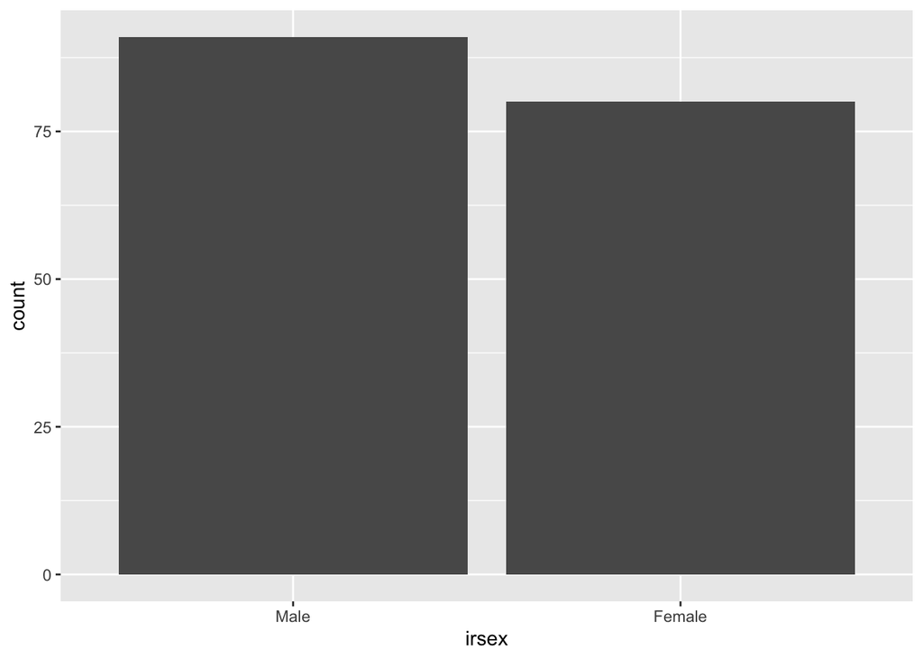

```r
# Note: This line makes the levels of the factors take on the values from the codebook. Run it before you make your plots to have clearer labels.

dat <- dat %>%
  mutate_at(c('irsex', 'sexatract', 'speakengl'), as.factor) %>%
  mutate(irsex = recode(irsex,         "1"="Male", "2"="Female"),
         sexatract = recode(sexatract, "1"="I am only attracted to opposite sex",
                                       "2"="I am mostly attracted to opposite sex",
                                       "3"="I am equally attracted to males and females",
                                       "4"="I am mostly attracted to same sex",
                                       "5"="I am only attracted to same sex",
                                       "6"="I am not sure",
                                       "99"="Legitimate skip"),
         speakengl = recode(speakengl, "1"="Very well",
                                       "2"="Well",
                                       "3"="Not well",
                                       "4"="Not at all"))

#visual eda irsex

dat %>%
  ggplot(aes(irsex)) +
  geom_bar()
```

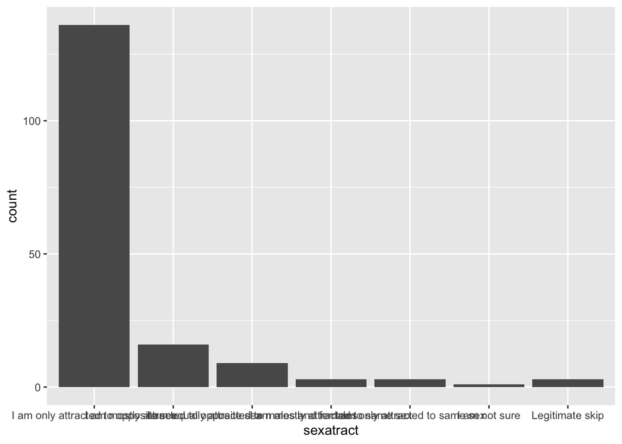

```r
#visual EDA sexatract

dat %>%
  ggplot(aes(sexatract)) +
  geom_bar()
```

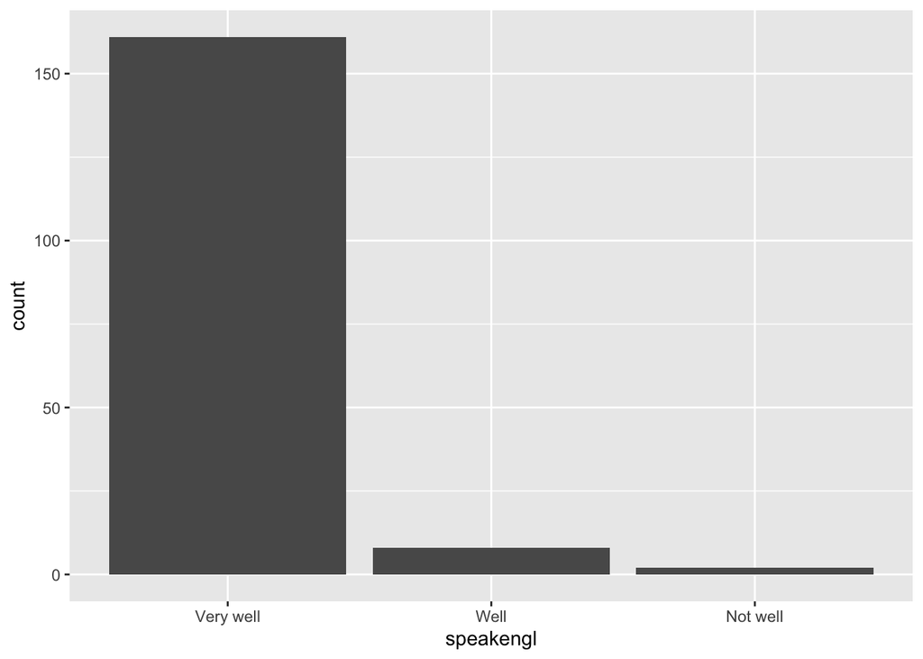

```r
#i made one for speakengl too because the next question asks something abt it and i didnt know where to stick it
dat %>%
  ggplot(aes(speakengl)) +
  geom_bar()
```

Answer: l learned that for irsex, it only seems like there is a pretty even distribution as only a slightly larger number of men than women that are recorded, and for seattract there seems to be a very amount of people only are attracted to the opposite sex, as opposed to the minuscule amounts for the other variables. this can indicate that most people in this dataset that are recorded are heterosexual and may be more likely to be a man than a woman.

### 7. (5 points) Do quantitative EDA for irsex, sexatract, and speakengl. What do you learn from this that you didn’t know from the visual EDA?

```r
table(dat$irsex)
```

```
##
##   Male Female
##     91     80
```

```r
dat %>%
 count(irsex) %>%
 mutate(prop = prop.table(n))
```

```
## # A tibble: 2 × 3
##   irsex      n  prop
##   <fct>  <int> <dbl>
## 1 Male      91 0.532
## 2 Female    80 0.468
```

```r
table(dat$sexatract)
```

```
##
##         I am only attracted to opposite sex
##                                         136
##       I am mostly attracted to opposite sex
##                                          16
## I am equally attracted to males and females
##                                           9
##           I am mostly attracted to same sex
##                                           3
##             I am only attracted to same sex
##                                           3
##                               I am not sure
##                                           1
##                             Legitimate skip
##                                           3
```

```r
dat %>%
 count(sexatract) %>%
 mutate(prop = prop.table(n))
```

```
## # A tibble: 7 × 3
##   sexatract                                       n    prop
##   <fct>                                       <int>   <dbl>
## 1 I am only attracted to opposite sex           136 0.795
## 2 I am mostly attracted to opposite sex          16 0.0936
## 3 I am equally attracted to males and females     9 0.0526
## 4 I am mostly attracted to same sex               3 0.0175
## 5 I am only attracted to same sex                 3 0.0175
## 6 I am not sure                                   1 0.00585
## 7 Legitimate skip                                 3 0.0175
```

```r
table(dat$speakengl)
```

```
##
## Very well      Well  Not well
##       161         8         2
```

```r
dat %>%
 count(speakengl) %>%
 mutate(prop = prop.table(n))
```

```
## # A tibble: 3 × 3
##   speakengl     n   prop
##   <fct>     <int>  <dbl>
## 1 Very well   161 0.942
## 2 Well          8 0.0468
## 3 Not well      2 0.0117
```

Answer: The data lines up pretty nicely from what I already knew in the visual table to the quantitative table, but the quantitiaitve eda is helpful because it gives us the specific number and proportion of what was shown in the visual table, this is helpful because it makes understanding the variables numerically and in proportion to one another more apparent. Also i learned that a large number of people in this set speak english well; meaning that the demograhipc of this set could most likey be heterosexual men and women (more emphasis on men) that speak english well.

### 8. (5 points) Copy your line from the visual EDA for mjage. What happens when you use this code “aes(x=mjage, fill=sexatract)” for the aesethetics in ggplot? Do you find out something interesting?

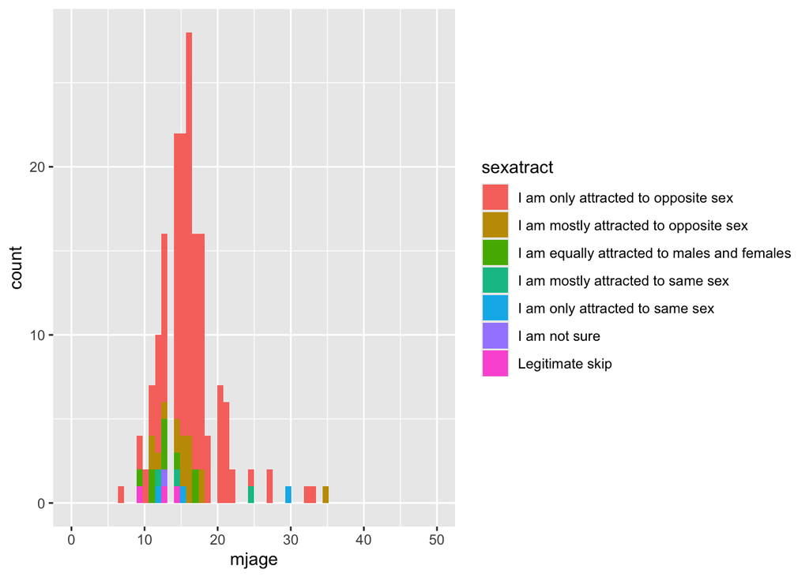

```r
dat %>%
  ggplot(aes(x=mjage, fill=sexatract))+
  geom_histogram(bins=60)+
  xlim(0,50)
```

Answer: it gives us a very coloful map that maps out the sexual attraction of the people during their first age of their first tme trying marijuana. it looks almost like a contingency table because it shows both variables; mjage (age of first onset of marijuana use) and uses that to look at the sexual attraction of the people who used the marijuana at sepcific ages for the first time. The colors are helpful in order to figure out the propotion of the people’s attatacttion during the onset of their marijuanan usage